# GIS Data

Lauren Chan

2022-09-13

# 0. Load the libraries

```r
library(raster)
library(sp)
library(rgdal)
library(ggplot2)
library(RColorBrewer)
library(yarrr)
library(ggsci)
```

# 1. Ready the Data

## 1.1 Load Raster Data and convert to dataframe

```r
# Load Rasters
north_cover <- raster("cover_North.tif")
south_cover <- raster("cover_South.tif")

# Convert Raster to data.frames for use with ggplot2
ncover_df <- data.frame(rasterToPoints(north_cover, spatial=TRUE))
names(ncover_df)   # Note that first column is called "cover_North"
```

```
## [1] "cover_North" "x"           "y"           "optional"
```

```r
## Could do same with South dataset...
```

## 1.2 Load Point Data, project coordinate system, save as data.frame.

```r
# Load points
pts <- read.delim("WAsamples_Sep7.txt", sep=",", strip.white=TRUE)

# Change coordinate system and convert to data.frame
coordinates(pts) <- c("Longitude", "Latitude")
projection(pts) <- CRS("+init=epsg:4326")
pts <- spTransform(pts, CRS("+proj=utm +zone=10"))
pts <- as.data.frame(pts)
names(pts) <- c("SampleID", "Species", "Basin", "x", "y")   # Rename columns
```

Also, subset North and South Points

```r
npts <- pts[pts$Basin!="Upper Chehalis",]  # != is NOT equal
spts <- pts[pts$Basin=="Upper Chehalis",]  # == is equal
```

# 2. Visualize

## 2.1 Color Palettes

```r
ras.pal <- colorRampPalette(brewer.pal(12, "Set3"))(19)
pts.pal <- as.vector(pal_jama()(3))
```

## 2.2 Read and setup raster keys

```r
key <- read.delim("NCover_Key.txt")
names(ras.pal) <- key$Value
```

## 2.3 Plot

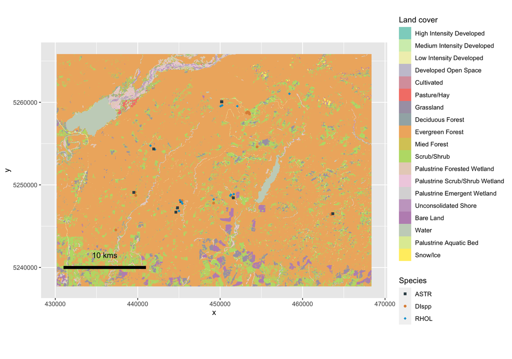

```r
mymap <- ggplot(data=ncover_df) +
  geom_raster(aes(x=x, y=y, fill=as.character(cover_North))) +
  coord_equal() +
  scale_fill_manual(name="Land cover",
                    values=ras.pal,
                    labels=key[,2],
                    na.translate=F, ) +
  geom_jitter(data=npts,
              aes(x=x, y=y, color=Species, shape=Species),
              width=300, height=300) +
  scale_color_manual(values=pts.pal) +
  scale_shape_manual(values=c(15,16,18)) +
  annotate("text", x = 436000, y = 5241500, label = "10 kms") +
  annotate("segment", x=431000, xend=441000, y=5240000, yend=5240000,
           color="black", size=2)
mymap
```

# 3. Reclassify Data

Often, there are too many values in these landcover datasets and it’s easier to visualize after simplifying. Here, we’ll clump together certain landcover variables and create a simplified dataset. This is called “reclassifying the data”

## 3.1 Look at data and decide how reclassify.

Open up the key dataset and look at the values and the landcover types.

```r
key$Value
```

```
##  [1]  2  3  4  5  6  7  8  9 10 11 12 13 14 15 19 20 21 22 25
```

```r
key$Landcover
```

```
##  [1] "High Intensity Developed"       "Medium Intensity Developed"
##  [3] "Low Intensity Developed"        "Developed Open Space"
##  [5] "Cultivated"                     "Pasture/Hay"
##  [7] "Grassland"                      "Deciduous Forest"
##  [9] "Evergreen Forest"               "Mied Forest"
## [11] "Scrub/Shrub"                    "Palustrine Forested Wetland"
## [13] "Palustrine Scrub/Shrub Wetland" "Palustrine Emergent Wetland"
## [15] "Unconsolidated Shore"           "Bare Land"
## [17] "Water"                          "Palustrine Aquatic Bed"
## [19] "Snow/lce"
```

We might simplify by grouping all developed land cover, agriculture, forest, wetland, etc. It’s often handy to use Google Sheets as a worksheet for this.

We set up a new set of classes. We put these with the original key and make sure they’re all entered correctly

```r
newvals <- c(1,1,1,1,2,2,3,4,4,4,5,6,6,6,7,8,9,10,11)
data.frame(key,newvals)
```

```
##    Value                      Landcover newvals
## 1      2       High Intensity Developed       1
## 2      3     Medium Intensity Developed       1
## 3      4        Low Intensity Developed       1
## 4      5           Developed Open Space       1
## 5      6                     Cultivated       2
## 6      7                    Pasture/Hay       2
## 7      8                      Grassland       3
## 8      9               Deciduous Forest       4
## 9     10               Evergreen Forest       4
## 10    11                    Mied Forest       4
## 11    12                    Scrub/Shrub       5
## 12    13    Palustrine Forested Wetland       6
## 13    14 Palustrine Scrub/Shrub Wetland       6
## 14    15    Palustrine Emergent Wetland       6
## 15    19           Unconsolidated Shore       7
## 16    20                      Bare Land       8
## 17    21                          Water       9
## 18    22         Palustrine Aquatic Bed      10
## 19    25                       Snow/lce      11
```

Then we create a lookup table matching old values and new values.

```r
lookup <- data.frame(key$Value,newvals)
```

Now, we can reclassify using subs(). Note that we want to do this to the *original raster* we loaded, NOT the data.frame we converted it to.

```r
# naming for NorthLandCover_ReClass (nlc_rc)
# Note that we do this to the original raster, north_cover, NOT ncover_df
nlc_rc <- subs(north_cover, lookup)

# Convert new reclassified raster back to dataframe
nlc_rcDF <- data.frame(rasterToPoints(nlc_rc, spatial=TRUE))
names(nlc_rcDF)
```

```
## [1] "newvals"  "x"        "y"        "optional"
```

Enter the new names and colors:

```r
newnames <- c("developed", "agriculture", "grassland",
              "forest", "scrub/shrub", "wetland",
              "shore", "bareland", "water",
              "aquatic bed", "snow/ice")
new.key <- data.frame(Value=unique(newvals), Landcover=newnames)
new.pal <- as.vector(pal_simpsons()(11))
names(new.pal) <- new.key$Value
```

Plot. Need to change data to correct dataframe and the fill in raster to the column that has the categories (newvals). Also, need to set up the new key.

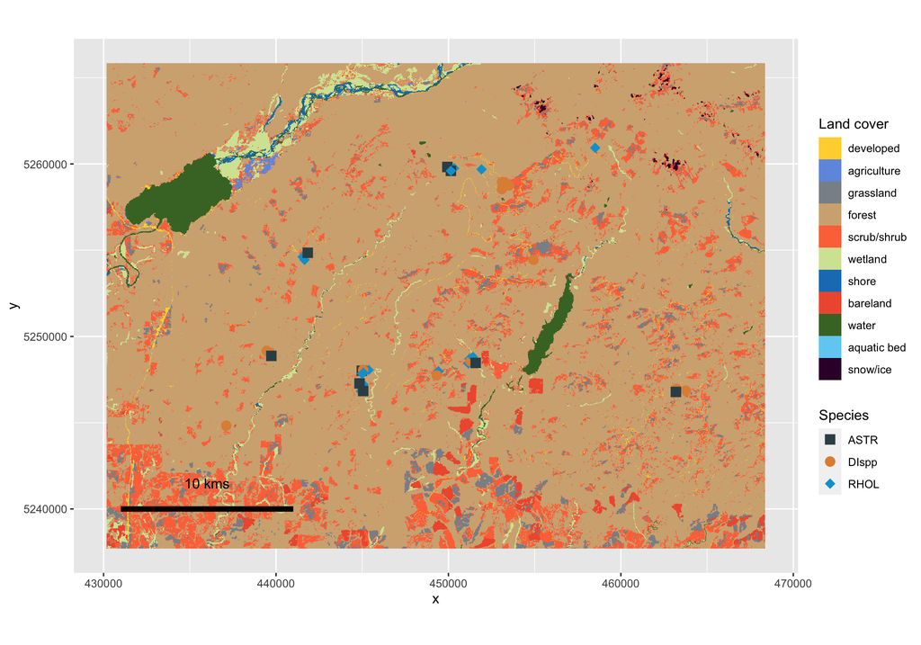

```r
mymap <- ggplot(data=nlc_rcDF) +
  geom_raster(aes(x=x, y=y, fill=as.character(newvals))) +
  coord_equal() +
  scale_fill_manual(name="Land cover",
                    values=new.pal,
                    labels=new.key$Landcover,
                    na.translate=F, ) +
  geom_jitter(data=npts, aes(x=x, y=y, color=Species, shape=Species), cex=3.5, width=300, height=300) +
  scale_color_manual(values=pts.pal) +
  scale_shape_manual(values=c(15,16,18)) +
  annotate("text", x = 436000, y = 5241500, label = "10 kms") +
  annotate("segment", x=431000, xend=441000, y=5240000, yend=5240000,
           color="black", size=2)
mymap
```

# 4. Look at particular habitat types

We can visualize particular habitat types at a time by working with our original or reclassified raster (again, not the converted data.frame). Here I’ll work with my reclassified raster. I can look at new.key to make sure I’m selecting the right values!

```r
developed <- nlc_rc == 1
forest <- nlc_rc == 4
wetland <- nlc_rc == 6
```

Convert to df

```r
developedDF <- data.frame(rasterToPoints(developed, spatial=TRUE))
```

Plot

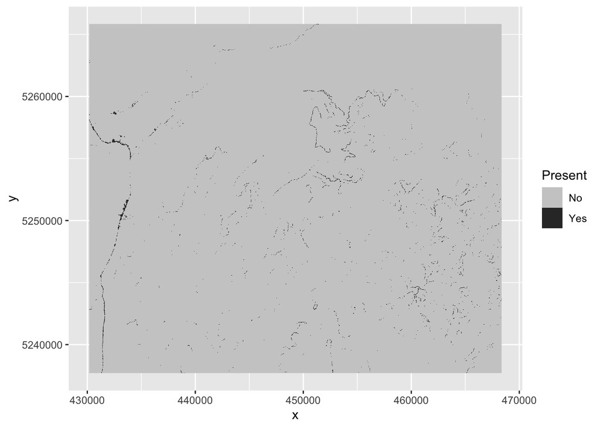

```r
ggplot(data = developedDF) +
  geom_raster(aes(x = x, y = y, fill = as.character(layer))) +
  scale_fill_manual(name = "Present",
                    values = c("gray80", "gray20"),
                    labels = c("No", "Yes"),
                    na.translate = FALSE)
```

Plot

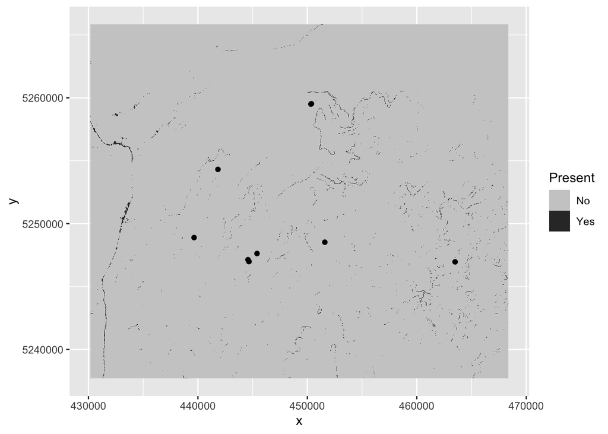

```r
nastr <- npts[npts$Species=="ASTR",]
ggplot(data = developedDF) +
  geom_raster(aes(x = x, y = y, fill = as.character(layer))) +
  scale_fill_manual(name = "Present",
                    values = c("gray80", "gray20"),
                    labels = c("No", "Yes"),
                    na.translate = FALSE) +
  geom_jitter(data=nastr, aes(x=x, y=y), width=300, height=300)
```